# MA_Hw_05_03

## Packages

```r
suppressMessages(library(plyr))
suppressMessages(library(rethinking))
suppressMessages(library(rstan))
suppressMessages(library(tidyverse))
suppressMessages(library(ggplot2))
suppressMessages(library(skimr)) # for n_unique func
```

## Data-processing

### Read data

```r
data("bangladesh")
bangladesh
```

| woman | district | use.contraception | living.children | age.centered | urban |
| --- | --- | --- | --- | --- | --- |
| 1 | 1 | 0 | 4 | 18.4400 | 1 |
| 2 | 1 | 0 | 1 | -5.5599 | 1 |
| 3 | 1 | 0 | 3 | 1.4400 | 1 |
| 4 | 1 | 0 | 4 | 8.4400 | 1 |
| 5 | 1 | 0 | 1 | -13.5590 | 1 |
| 6 | 1 | 0 | 1 | -11.5600 | 1 |
| 7 | 1 | 0 | 4 | 18.4400 | 1 |
| 8 | 1 | 0 | 4 | -3.5599 | 1 |
| 9 | 1 | 0 | 2 | -5.5599 | 1 |
| 10 | 1 | 0 | 4 | 1.4400 | 1 |

[output cut: 1924 more lines]

### Select data

I select the data which might be used first

```r
train = bangladesh %>%
  dplyr::select("district", "use.contraception", "urban")

train$ad_district = as.integer(as.factor(train$district))
train
```

| district | use.contraception | urban | ad_district |
| --- | --- | --- | --- |
| 1 | 0 | 1 | 1 |
| 1 | 0 | 1 | 1 |
| 1 | 0 | 1 | 1 |
| 1 | 0 | 1 | 1 |
| 1 | 0 | 1 | 1 |
| 1 | 0 | 1 | 1 |
| 1 | 0 | 1 | 1 |
| 1 | 0 | 1 | 1 |
| 1 | 0 | 1 | 1 |
| 1 | 0 | 1 | 1 |

[output cut: 1924 more lines]

### Group data

I group datas by district

```r
train_gp_dis =
  train %>%
  group_by(ad_district) %>%
  summarise(use.contraception = sum(use.contraception)) %>%
  ungroup()
train_gp_dis =
  train_gp_dis %>%
  cbind( ., (train %>% count(ad_district))[,"n"])

train_gp_dis
```

| ad_district | use.contraception | n |
| --- | --- | --- |
| 1 | 30 | 117 |
| 2 | 7 | 20 |
| 3 | 2 | 2 |
| 4 | 15 | 30 |
| 5 | 14 | 39 |
| 6 | 19 | 65 |
| 7 | 5 | 18 |
| 8 | 14 | 37 |
| 9 | 7 | 23 |
| 10 | 1 | 13 |

[output cut: 50 more lines]

## PART A

### Model

#### Fixed Prior Model

For the parameters,  
I set a to be the coefficients of different district.

```r
q3_model_fixed = "
data {
    int N_district;
    int district[N_district];
    int contrace[N_district];
    int num_woman[N_district];
}

parameters {
    real a[N_district];
}

transformed parameters {
    real p[N_district];

    for (i in 1:N_district){
        p[i] = inv_logit(a[i]);
  }
}

model {
    for (i in 1:N_district){
        contrace[i] ~ binomial(num_woman[i], p[i]);
    }
    a ~ normal(0, 0.5);
}

generated quantities {
    real log_lik[N_district];
    real pred_y[N_district];

    for (i in 1:N_district){
        log_lik[i] = binomial_lpmf(contrace[i] | num_woman[i], p[i]);
        pred_y[i] = binomial_rng(num_woman[i], p[i]);
    }

}

"
```

```r
q3_data_fixed = list(
          N_district = nrow(train_gp_dis),
          district = train_gp_dis$ad_district,
          contrace = train_gp_dis$use.contraception,
          num_woman = train_gp_dis$n
)
```

### Fit

```r
q3_fit_fixed = stan(
                  model_code = q3_model_fixed,
                  data = q3_data_fixed,
                  cores = 2, chains = 2,
                  warmup = 2000, iter = 4000)
```

```
starting worker pid=28263 on localhost:11275 at 22:57:00.010
starting worker pid=28277 on localhost:11275 at 22:57:00.299
```

```
Tail Effective Samples Size (ESS) is too low, indicating posterior variances and tail quantiles may be unreliable.
Running the chains for more iterations may help. See
http://mc-stan.org/misc/warnings.html#tail-ess
```

### Check the posteriors

we can see that all the R hat of paras are 1, which means they are convergent

```r
options(max.print=1000000)
print(q3_fit_fixed, pars = c("a"))
```

```
Inference for Stan model: 271d1413de0ca4919a5c4b4670ea6aa5.
2 chains, each with iter=4000; warmup=2000; thin=1;
post-warmup draws per chain=2000, total post-warmup draws=4000.

       mean se_mean   sd  2.5%   25%   50%   75% 97.5% n_eff Rhat
a[1]  -0.92    0.00 0.19 -1.28 -1.04 -0.91 -0.79 -0.55  4950    1
a[2]  -0.33    0.00 0.34 -1.01 -0.56 -0.33 -0.11  0.31  4947    1
a[3]   0.23    0.01 0.47 -0.71 -0.08  0.23  0.55  1.16  5203    1
a[4]   0.00    0.00 0.30 -0.58 -0.21  0.00  0.21  0.58  6342    1
a[5]  -0.40    0.00 0.28 -0.96 -0.59 -0.40 -0.22  0.16  4823    1
a[6]  -0.70    0.00 0.23 -1.17 -0.85 -0.70 -0.54 -0.24  6209    1
a[7]  -0.48    0.00 0.35 -1.17 -0.71 -0.48 -0.25  0.18  5217    1
a[8]  -0.34    0.00 0.28 -0.89 -0.53 -0.34 -0.15  0.18  6200    1
a[9]  -0.46    0.00 0.32 -1.10 -0.68 -0.46 -0.24  0.18  5396    1
a[10] -0.78    0.00 0.38 -1.55 -1.03 -0.77 -0.53 -0.03  5740    1
a[11] -1.22    0.00 0.36 -1.94 -1.47 -1.22 -0.97 -0.53  5521    1
a[12] -0.40    0.00 0.30 -0.99 -0.60 -0.41 -0.20  0.19  5703    1
a[13] -0.21    0.00 0.32 -0.86 -0.42 -0.20  0.01  0.41  5185    1
a[14]  0.46    0.00 0.18  0.11  0.34  0.46  0.58  0.81  5296    1
a[15] -0.32    0.00 0.33 -1.00 -0.54 -0.32 -0.10  0.31  5694    1
a[16]  0.12    0.00 0.34 -0.55 -0.11  0.11  0.34  0.81  5316    1
a[17] -0.51    0.00 0.32 -1.16 -0.73 -0.52 -0.29  0.11  5219    1
a[18] -0.49    0.00 0.26 -1.01 -0.66 -0.48 -0.31  0.00  4958    1
a[19] -0.29    0.00 0.32 -0.93 -0.50 -0.29 -0.08  0.33  6063    1
a[20] -0.19    0.00 0.37 -0.92 -0.43 -0.20  0.05  0.53  5582    1
a[21] -0.24    0.00 0.34 -0.88 -0.48 -0.24  0.00  0.46  5334    1
a[22] -0.69    0.00 0.34 -1.35 -0.93 -0.69 -0.46 -0.03  6695    1
a[23] -0.46    0.01 0.37 -1.20 -0.71 -0.45 -0.20  0.26  5272    1
a[24] -0.83    0.01 0.39 -1.60 -1.09 -0.82 -0.57 -0.08  5554    1
a[25] -0.17    0.00 0.22 -0.59 -0.32 -0.17 -0.02  0.25  5927    1
a[26] -0.21    0.00 0.38 -0.96 -0.46 -0.21  0.05  0.53  5800    1
a[27] -1.00    0.00 0.28 -1.56 -1.19 -1.00 -0.81 -0.47  6034    1
a[28] -0.81    0.00 0.26 -1.33 -0.98 -0.81 -0.64 -0.31  4450    1
a[29] -0.61    0.00 0.30 -1.20 -0.81 -0.60 -0.40 -0.04  6152    1
a[30] -0.03    0.00 0.23 -0.48 -0.18 -0.03  0.12  0.41  5107    1
a[31] -0.12    0.00 0.28 -0.67 -0.32 -0.12  0.07  0.42  5329    1
a[32] -0.73    0.00 0.32 -1.38 -0.94 -0.73 -0.51 -0.10  5681    1
a[33] -0.14    0.00 0.37 -0.86 -0.39 -0.14  0.10  0.59  6301    1
a[34]  0.44    0.00 0.28 -0.11  0.25  0.44  0.63  1.02  4345    1
a[35]  0.00    0.00 0.25 -0.48 -0.16  0.01  0.17  0.49  5006    1
```

[output cut: 15 more lines]

```
a[51] -0.12    0.00 0.28 -0.68 -0.31 -0.11  0.08  0.43  6557    1
a[52] -0.18    0.00 0.23 -0.62 -0.34 -0.18 -0.02  0.27  6030    1
a[53] -0.18    0.00 0.33 -0.82 -0.40 -0.18  0.03  0.47  5460    1
a[54] -0.36    0.01 0.44 -1.23 -0.66 -0.35 -0.07  0.45  5356    1
a[55]  0.23    0.00 0.26 -0.27  0.06  0.23  0.41  0.74  4939    1
a[56] -0.83    0.00 0.33 -1.52 -1.04 -0.83 -0.60 -0.20  5353    1
a[57] -0.13    0.00 0.28 -0.70 -0.31 -0.13  0.06  0.43  6024    1
a[58] -0.63    0.01 0.41 -1.47 -0.90 -0.62 -0.36  0.15  5646    1
a[59] -0.78    0.00 0.31 -1.40 -0.99 -0.78 -0.57 -0.20  5393    1
a[60] -0.88    0.00 0.29 -1.44 -1.07 -0.87 -0.68 -0.33  6174    1

Samples were drawn using NUTS(diag_e) at Sun Jun  7 22:57:04 2020.
For each parameter, n_eff is a crude measure of effective sample size,
and Rhat is the potential scale reduction factor on split chains (at
convergence, Rhat=1).
```

## PART B

### Model

#### Multilevel model

For the parameters,  
I set a to be the coefficients of different district,  
and set a_bar and a_sigma for the parameters which a is given by.

```r
q3_model_multi = "
data {
    int N_district;
    int district[N_district];
    int contrace[N_district];
    int num_woman[N_district];
}

parameters {
    real a[N_district];
    real a_bar;
    real<lower=0> a_sigma;
}

transformed parameters {
    real p[N_district];

    for (i in 1:N_district){
        p[i] = inv_logit(a[i]);
  }
}

model {
  // adative prior
  a ~ normal(a_bar, a_sigma);
  a_bar ~ normal(0, 1.5);
  a_sigma ~ exponential(1);

  // model
    for (i in 1:N_district){
        contrace[i] ~ binomial(num_woman[i], p[i]);
    }

}

generated quantities {
    real log_lik[N_district];
    real pred_y[N_district];
    for (i in 1:N_district){
        log_lik[i] = binomial_lpmf(contrace[i] | num_woman[i], p[i]);
        pred_y[i] = binomial_rng(num_woman[i], p[i]);
    }
}

"
```

```r
q3_data_multi = q3_data_fixed
```

### Fit

```r
q3_fit_multi = stan(
                  model_code = q3_model_multi,
                  data = q3_data_multi,
                  cores = 2, chains = 2,
                  warmup = 1500, iter = 3000)
```

```
recompiling to avoid crashing R session
```

```
starting worker pid=28346 on localhost:11275 at 22:58:26.134
starting worker pid=28360 on localhost:11275 at 22:58:26.436
```

```
Tail Effective Samples Size (ESS) is too low, indicating posterior variances and tail quantiles may be unreliable.
Running the chains for more iterations may help. See
http://mc-stan.org/misc/warnings.html#tail-ess
```

### Check the posteriors

we can see that all the R hat of paras are 1, which means they are convergent

```r
options(max.print=1000000)
print(q3_fit_multi, pars = c("a", "a_bar", "a_sigma"))
```

```
Inference for Stan model: 5652e15b478d753a2ccd090a4aa0ff2f.
2 chains, each with iter=3000; warmup=1500; thin=1;
post-warmup draws per chain=1500, total post-warmup draws=3000.

         mean se_mean   sd  2.5%   25%   50%   75% 97.5% n_eff Rhat
a[1]    -1.00    0.00 0.19 -1.40 -1.12 -0.99 -0.86 -0.64  4137    1
a[2]    -0.59    0.00 0.33 -1.26 -0.81 -0.59 -0.37  0.05  4890    1
a[3]    -0.24    0.01 0.50 -1.20 -0.57 -0.26  0.10  0.75  4729    1
a[4]    -0.18    0.00 0.30 -0.76 -0.38 -0.18  0.02  0.39  4663    1
a[5]    -0.57    0.00 0.28 -1.14 -0.76 -0.57 -0.37 -0.04  4363    1
a[6]    -0.82    0.00 0.24 -1.28 -0.97 -0.81 -0.66 -0.36  4599    1
a[7]    -0.75    0.01 0.36 -1.49 -0.99 -0.75 -0.50 -0.06  4115    1
a[8]    -0.51    0.00 0.28 -1.07 -0.69 -0.51 -0.33  0.03  5285    1
a[9]    -0.71    0.00 0.34 -1.39 -0.93 -0.70 -0.48 -0.05  5493    1
a[10]   -1.14    0.01 0.43 -2.06 -1.42 -1.12 -0.84 -0.36  3257    1
a[11]   -1.55    0.01 0.43 -2.48 -1.83 -1.53 -1.25 -0.79  2891    1
a[12]   -0.61    0.00 0.32 -1.28 -0.81 -0.60 -0.40  0.03  4806    1
a[13]   -0.42    0.00 0.33 -1.07 -0.64 -0.42 -0.20  0.21  4726    1
a[14]    0.39    0.00 0.18  0.05  0.26  0.39  0.52  0.73  4156    1
a[15]   -0.56    0.00 0.34 -1.22 -0.78 -0.56 -0.33  0.09  5634    1
a[16]   -0.13    0.00 0.33 -0.77 -0.36 -0.12  0.09  0.54  4670    1
a[17]   -0.75    0.01 0.34 -1.43 -0.99 -0.75 -0.51 -0.12  4520    1
a[18]   -0.63    0.00 0.26 -1.16 -0.81 -0.62 -0.45 -0.12  5429    1
a[19]   -0.49    0.00 0.31 -1.11 -0.70 -0.49 -0.29  0.11  4239    1
a[20]   -0.48    0.01 0.37 -1.21 -0.73 -0.48 -0.24  0.24  4756    1
a[21]   -0.50    0.01 0.36 -1.21 -0.75 -0.51 -0.27  0.20  4363    1
a[22]   -0.96    0.01 0.37 -1.72 -1.19 -0.95 -0.70 -0.26  3906    1
a[23]   -0.77    0.01 0.38 -1.56 -1.02 -0.76 -0.50 -0.04  4639    1
a[24]   -1.18    0.01 0.42 -2.07 -1.44 -1.16 -0.90 -0.39  3364    1
a[25]   -0.28    0.00 0.22 -0.72 -0.43 -0.27 -0.12  0.14  4765    1
a[26]   -0.52    0.01 0.40 -1.32 -0.77 -0.51 -0.25  0.25  4668    1
a[27]   -1.19    0.00 0.31 -1.78 -1.39 -1.19 -0.97 -0.61  3872    1
a[28]   -0.97    0.00 0.29 -1.53 -1.15 -0.96 -0.78 -0.42  4719    1
a[29]   -0.80    0.00 0.31 -1.43 -1.00 -0.80 -0.60 -0.19  4980    1
a[30]   -0.13    0.00 0.24 -0.60 -0.30 -0.13  0.03  0.33  5113    1
a[31]   -0.30    0.00 0.29 -0.87 -0.49 -0.30 -0.11  0.29  4767    1
a[32]   -0.98    0.01 0.35 -1.71 -1.21 -0.96 -0.74 -0.34  4542    1
a[33]   -0.42    0.01 0.37 -1.15 -0.67 -0.42 -0.17  0.28  4825    1
a[34]    0.27    0.00 0.31 -0.32  0.07  0.27  0.48  0.89  4715    1
a[35]   -0.14    0.00 0.25 -0.61 -0.31 -0.14  0.03  0.37  5408    1
```

[output cut: 17 more lines]

```
a[53]   -0.42    0.01 0.35 -1.09 -0.66 -0.42 -0.18  0.25  4178    1
a[54]   -0.80    0.01 0.46 -1.69 -1.10 -0.79 -0.48  0.05  4355    1
a[55]    0.09    0.00 0.27 -0.43 -0.09  0.08  0.26  0.65  5038    1
a[56]   -1.07    0.01 0.35 -1.79 -1.30 -1.06 -0.84 -0.42  3649    1
a[57]   -0.30    0.00 0.30 -0.88 -0.50 -0.30 -0.10  0.27  6113    1
a[58]   -1.01    0.01 0.43 -1.90 -1.30 -1.00 -0.73 -0.19  3631    1
a[59]   -0.99    0.00 0.33 -1.66 -1.20 -0.98 -0.76 -0.39  4796    1
a[60]   -1.06    0.00 0.31 -1.70 -1.26 -1.05 -0.85 -0.49  4111    1
a_bar   -0.54    0.00 0.09 -0.72 -0.60 -0.53 -0.48 -0.37  3171    1
a_sigma  0.52    0.00 0.08  0.37  0.46  0.51  0.57  0.69  1125    1

Samples were drawn using NUTS(diag_e) at Sun Jun  7 22:58:30 2020.
For each parameter, n_eff is a crude measure of effective sample size,
and Rhat is the potential scale reduction factor on split chains (at
convergence, Rhat=1).
```

## PART C

### Tidy up data

```r
q3_post_A = as.data.frame(q3_fit_fixed, pars = "pred_y")

q3_post_A = data.frame(
                    pred_mean_y = q3_post_A %>% apply(., 2, mean),
                    PI_lower = q3_post_A %>% apply(., 2, HPDI) %>% .[1,],
                    PI_upper = q3_post_A %>% apply(., 2, HPDI) %>% .[2,])

q3_post_B = as.data.frame(q3_fit_multi, pars = "pred_y")

q3_post_B = data.frame(
                    pred_mean_y = q3_post_B %>% apply(., 2, mean),
                    PI_lower = q3_post_B %>% apply(., 2, HPDI) %>% .[1,],
                    PI_upper = q3_post_B %>% apply(., 2, HPDI) %>% .[2,])

q3_pred_y_A = cbind("ad_district" = c(1:60), q3_post_A)
q3_pred_y_B = cbind("ad_district" = c(1:60), q3_post_B)
rownames(q3_pred_y_A) = c()
rownames(q3_pred_y_B) = c()
q3_pred_y_A = q3_pred_y_A %>%
              mutate(
                "propotion" =  pred_mean_y / q3_data_fixed$num_woman,
                "propotion_lower" = PI_lower  / q3_data_fixed$num_woman,
                "propotion_upper" = PI_upper / q3_data_fixed$num_woman

              )
q3_pred_y_B = q3_pred_y_B %>%
              mutate(
                "propotion" =  pred_mean_y / q3_data_fixed$num_woman,
                "propotion_lower" = PI_lower  / q3_data_fixed$num_woman,
                "propotion_upper" = PI_upper / q3_data_fixed$num_woman
              )

q3_pred_y_A
```

| ad_district | pred_mean_y | PI_lower | PI_upper | propotion | propotion_lower | propotion_upper |
| --- | --- | --- | --- | --- | --- | --- |
| 1 | 33.60300 | 22 | 43 | 0.2872051 | 0.18803419 | 0.3675214 |
| 2 | 8.41900 | 4 | 12 | 0.4209500 | 0.20000000 | 0.6000000 |
| 3 | 1.08925 | 0 | 2 | 0.5446250 | 0.00000000 | 1.0000000 |
| 4 | 15.11475 | 9 | 20 | 0.5038250 | 0.30000000 | 0.6666667 |
| 5 | 15.70575 | 9 | 21 | 0.4027115 | 0.23076923 | 0.5384615 |
| 6 | 21.67550 | 12 | 28 | 0.3334692 | 0.18461538 | 0.4307692 |
| 7 | 7.02875 | 2 | 10 | 0.3904861 | 0.11111111 | 0.5555556 |
| 8 | 15.40825 | 8 | 20 | 0.4164392 | 0.21621622 | 0.5405405 |
| 9 | 8.92275 | 4 | 13 | 0.3879457 | 0.17391304 | 0.5652174 |
| 10 | 4.14625 | 1 | 7 | 0.3189423 | 0.07692308 | 0.5384615 |

[output cut: 50 more lines]

```r
q3_pred_y_B
```

| ad_district | pred_mean_y | PI_lower | PI_upper | propotion | propotion_lower | propotion_upper |
| --- | --- | --- | --- | --- | --- | --- |
| 1 | 31.817667 | 20 | 41 | 0.2719459 | 0.17094017 | 0.3504274 |
| 2 | 7.149333 | 2 | 10 | 0.3574667 | 0.10000000 | 0.5000000 |
| 3 | 0.869000 | 0 | 2 | 0.4345000 | 0.00000000 | 1.0000000 |
| 4 | 13.590333 | 8 | 18 | 0.4530111 | 0.26666667 | 0.6000000 |
| 5 | 14.168667 | 8 | 20 | 0.3632991 | 0.20512821 | 0.5128205 |
| 6 | 20.125667 | 13 | 28 | 0.3096256 | 0.20000000 | 0.4307692 |
| 7 | 5.822000 | 2 | 9 | 0.3234444 | 0.11111111 | 0.5000000 |
| 8 | 13.888667 | 7 | 19 | 0.3753694 | 0.18918919 | 0.5135135 |
| 9 | 7.706667 | 4 | 12 | 0.3350725 | 0.17391304 | 0.5217391 |
| 10 | 3.243667 | 1 | 6 | 0.2495128 | 0.07692308 | 0.4615385 |

[output cut: 50 more lines]

### Plot

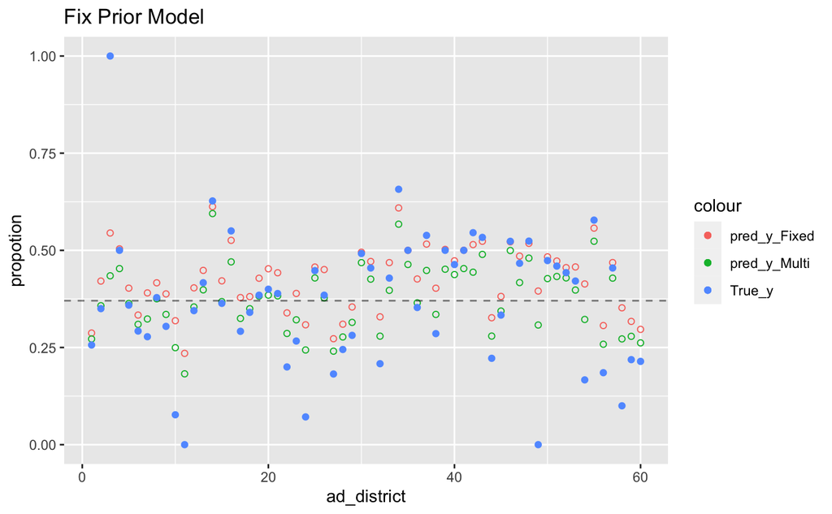

```r
q3_pic_AB = q3_pred_y_A %>%
  ggplot() +
  ggtitle("Fix Prior Model")+
  geom_point(aes(ad_district, propotion, color ="pred_y_Fixed"), shape=21)+
  geom_point(data = q3_pred_y_B, aes(ad_district, propotion, color ="pred_y_Multi"), shape=21)+
  geom_hline(yintercept = (q3_data_fixed$contrace/q3_data_fixed$num_woman) %>% mean, alpha=0.5, linetype="dashed") +
  geom_point(data = data.frame(q3_data_fixed), aes(c(1:60), contrace/num_woman, color ="True_y"), shape=19)

q3_pic_AB
```

## PART D

Also, we can see that, all the point of fixed estimate is larger than the multilevel estimate, which is because: In the fixed effect model, I set a ~ normal(0, 0.5),  
However, as the result of multilevel model, the a_bar(mu) is -0.54, and a_sigma(sigma) is 0.52.